# HW1: 各地區人口數與垃圾生產量的關係

詹雅芸

2019/7/15

## 目的

> 利用政府資料開放平台所提供的資料，建立各地區人口數與各地區垃圾生產量的關係

使用資料：

- [1-1 土地面積、戶數、人口數、人口密度、年齡結構及扶養比例](https://data.gov.tw/dataset/6326)
- [垃圾清理量資料](https://data.gov.tw/dataset/89022)

## 步驟

> 1. 匯入dplyr並讀取資料

```r
library(dplyr)
library(readr)

garbage_data <- read.csv("../../garbage.csv")
population_data <- read_csv("../../population.csv")
```

> 2. 將popularity_data中包含“區”(如北部區域)、“省”(如福建省)的「地區」篩掉，並選擇「地區」與「年底人口數」

人口相關資料(前5筆)

| 年 | 地區 | 土地面積 | 年底人口數男性 | 年底人口數女性 | 年底人口數 | 年底戶數 | 戶量 | 人口密度 | 外僑居住人數 | 年齡0~14歲 | 年齡0~14歲百分比 | 年齡15~64歲 | 年齡15~64歲百分比 | 年齡65歲以上 | 年齡65歲以上百分比 | 扶養百分比 |
| --- | --- | --- | --- | --- | --- | --- | --- | --- | --- | --- | --- | --- | --- | --- | --- | --- |
| 2017 | 臺閩地區 | 36197.0669 | 11719580 | 11851647 | 23571227 | 8649000 | 2.730000 | 651.1900 | 717736 | 3091873 | 13.12000 | 17211341 | 73.02000 | 3268013 | 13.86000 | 36.95172 |
| 2017 | 臺灣地區 | 36016.6109 | 11643509 | 11777382 | 23420891 | 8606223 | 2.721390 | 650.2803 | 716415 | 3076779 | 12.64000 | 17094291 | 72.10000 | 3249821 | 15.26000 | 37.01002 |
| 2017 | 北部區域 | 7353.3939 | 5241683 | 5437646 | 10679329 | 4059900 | 2.630441 | 1452.2993 | 345698 | 1462498 | 13.69466 | 7797268 | 73.01271 | 1419563 | 13.29262 | 36.96245 |
| 2017 | 臺北市 | 271.7997 | 1281917 | 1401340 | 2683257 | 1050755 | 2.550000 | 9872.1900 | 65388 | 369872 | 13.78000 | 1874209 | 69.85000 | 439176 | 16.37000 | 43.16744 |
| 2017 | 新北市 | 2052.5667 | 1953397 | 2033292 | 3986689 | 1543098 | 2.580000 | 1942.2900 | 101023 | 498155 | 12.50000 | 2986137 | 74.90000 | 502397 | 12.60000 | 33.50657 |

```r
p <- data.frame(population_data) %>%
  filter(!grepl("區", `地區`), !grepl("省", `地區`)) %>%
  select(county = `地區`, p_total = `年底人口數`)
```

> 3. 刪去不需要的資料，重新命名欄位，再修改資料型態以利後續操作

垃圾清理資料(前5筆)

| 序號 | 統計期 | 統計區 | 總計..公噸. | 一般垃圾..公噸. | 巨大垃圾..公噸. | 資源垃圾..公噸. | 廚餘..公噸. | 平均每人每日一般廢棄物產生量..公斤. |
| --- | --- | --- | --- | --- | --- | --- | --- | --- |
| 1 | 106年 | 新北市 | 1,158,662 | 390,679 | 47,834 | 606,677 | 113,473 | 0.797 |
| 2 | 106年 | 臺北市 | 755,026 | 205,932 | 14,031 | 468,299 | 66,764 | 0.769 |
| 3 | 106年 | 桃園市 | 890,147 | 379,199 | 1,187 | 487,301 | 22,460 | 1.125 |
| 4 | 106年 | 臺中市 | 863,140 | 357,187 | 5,165 | 457,481 | 43,308 | 0.852 |
| 5 | 106年 | 臺南市 | 671,386 | 238,233 | 20,209 | 339,573 | 73,372 | 0.975 |

```r
#原本的欄位名稱用``還是有error, 所以用索引值表示
g <- select(garbage_data, -c(1, 9),
            time_period = 2,
            county = 3,
            g_total = 4,
            g_garbage =  5,
            g_bulky = 6,
            g_recycle = 7,
            g_foodscrap = 8)

#改變資料型態(應該有更好的方法)
g$g_total <- as.numeric(gsub(",", "", g$g_total))
g$g_garbage <- as.numeric(gsub(",", "", g$g_garbage))
g$g_bulky <- as.numeric(gsub(",", "", g$g_bulky))
g$g_recycle <- as.numeric(gsub(",", "", g$g_recycle))
g$g_foodscrap <- as.numeric(gsub(",", "", g$g_foodscrap))

g_10612 <- filter(g, time_period == "106年 12月") %>%
  select(-c(1))
```

> 4. 將選擇的資料合併，並依照人口數由小到大排序

```r
#合併
merged_data <- merge(p, g_10612, by = "county")

#排序
merged_data <- merged_data[order(merged_data$p_total), ]
```

> > 加入新的欄位“單位垃圾生產量(kg/人)”

```r
merged_data <- mutate(merged_data, `g_percapita` = (g_total/p_total)*1000)
```

最終合併資料

| county | p_total | g_total | g_garbage | g_bulky | g_recycle | g_foodscrap | g_percapita |
| --- | --- | --- | --- | --- | --- | --- | --- |
| 連江縣 | 12880 | 651 | 180 | 36 | 300 | 135 | 50.54348 |
| 澎湖縣 | 104073 | 2999 | 1151 | 47 | 1456 | 345 | 28.81631 |
| 金門縣 | 137456 | 2374 | 540 | 42 | 1381 | 412 | 17.27098 |
| 臺東縣 | 219540 | 8793 | 2495 | 28 | 5606 | 664 | 40.05193 |
| 嘉義市 | 269398 | 10624 | 5738 | 138 | 4172 | 575 | 39.43608 |
| 花蓮縣 | 329237 | 10157 | 4202 | 22 | 5470 | 462 | 30.85012 |
| 基隆市 | 371458 | 14809 | 5509 | 216 | 8098 | 986 | 39.86723 |
| 新竹市 | 441132 | 14831 | 6289 | 262 | 7082 | 1198 | 33.62032 |
| 宜蘭縣 | 456607 | 12726 | 5312 | 294 | 6397 | 723 | 27.87079 |
| 南投縣 | 501051 | 15240 | 7400 | 97 | 6902 | 841 | 30.41607 |
| 嘉義縣 | 511182 | 15301 | 5658 | 83 | 8429 | 1131 | 29.93259 |
| 新竹縣 | 552169 | 15706 | 6865 | 150 | 8047 | 645 | 28.44419 |
| 苗栗縣 | 553807 | 20550 | 6701 | 299 | 12550 | 1000 | 37.10679 |
| 雲林縣 | 690373 | 15467 | 7020 | 234 | 6945 | 1268 | 22.40383 |
| 屏東縣 | 829939 | 27331 | 12760 | 467 | 13186 | 918 | 32.93134 |
| 彰化縣 | 1282458 | 35376 | 15979 | 518 | 17546 | 1332 | 27.58453 |
| 臺南市 | 1886522 | 60308 | 22718 | 1665 | 30405 | 5521 | 31.96782 |
| 桃園市 | 2188017 | 75145 | 32623 | 26 | 40602 | 1893 | 34.34388 |
| 臺北市 | 2683257 | 59237 | 14315 | 1184 | 38534 | 5204 | 22.07653 |
| 高雄市 | 2776912 | 85486 | 37058 | 931 | 40815 | 6682 | 30.78455 |
| 臺中市 | 2787070 | 72183 | 29093 | 383 | 39222 | 3484 | 25.89924 |
| 新北市 | 3986689 | 103232 | 50077 | 4096 | 42009 | 7051 | 25.89417 |

## 結論

> 利用`plot()`簡單的呈現結果

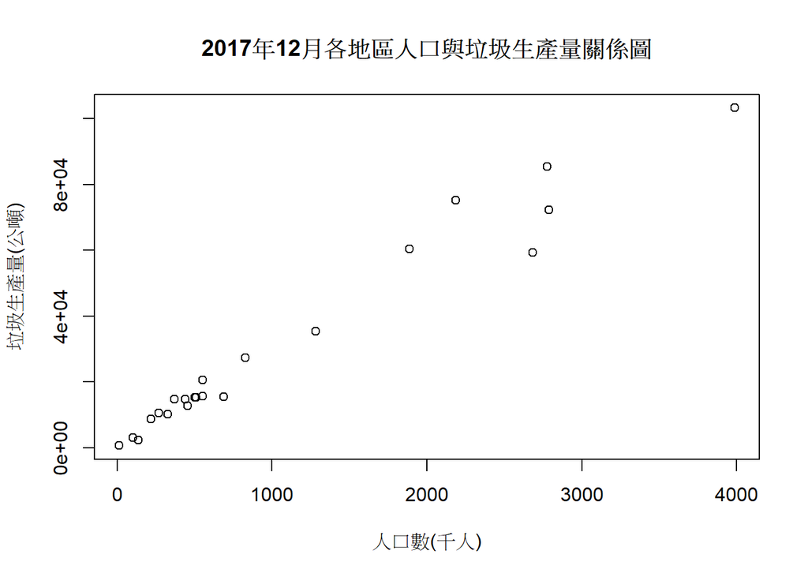

> 由上圖可知，人口數與垃圾生產量有顯著的正相關，人口越多的地區會產生越多的垃圾。 但若考慮下圖人口數與單位垃圾生產量(公斤/人)的關係，可以得知，人口數少的地區所產生的垃圾量，就比例而言偏多。  
> 註：為避免橫坐標數值出現科學記號，故將人口數以千人為單位表示

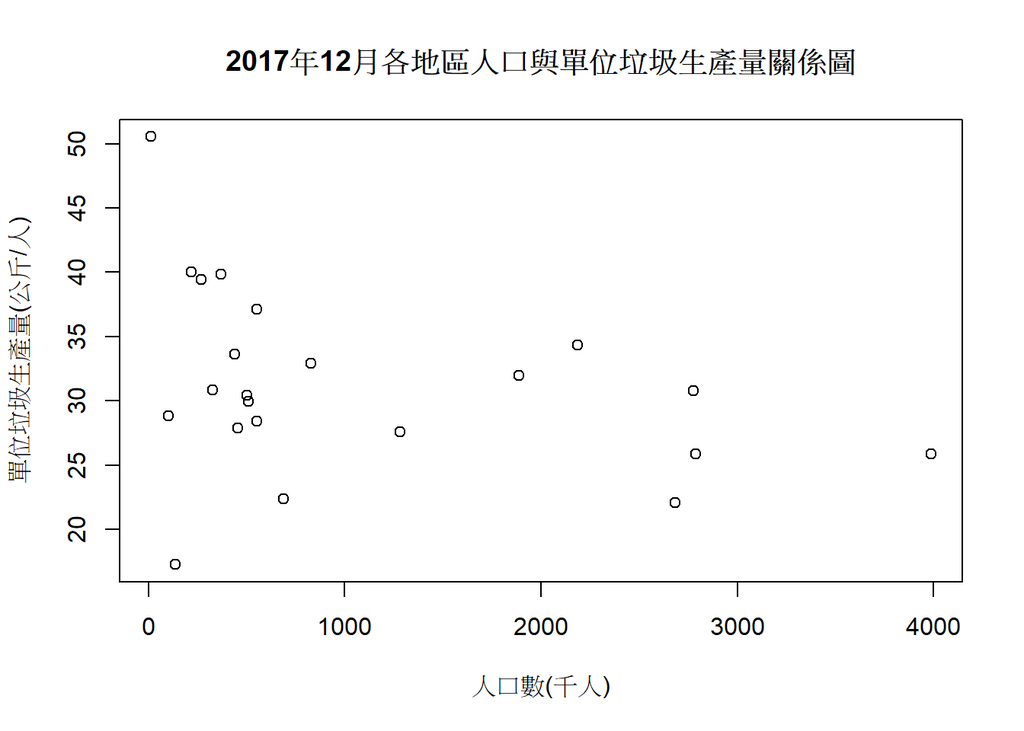